# Exam 1

Robert Campbell

Friday, March 5, 2021

Place your answers into this markdown document, knit it, and hand in the result as a PDF. There are 9 questions, each worth 10 points. Additionally, you get 10 points for handing in a PDF of a knit markdown document.

You may use R, the internet, and any reference material, but do not work together and do not get help (except from Dr. Clair).

### Honor Pledge

The work I have submitted represents my own effort. While working on this exam, I did not communicate in any form with individuals other than the instructor.

Signed: Robert V. Campbell

### Problem 1

Suppose you roll an ordinary six sided die 20 times and add up the total. What is the probability the sum is 55 or less?

```r
x<-replicate(10000,sum(sample(1:6,20,replace=TRUE)))
mean(x<56)
```

[output not shown]

### Problem 2

McDonald’s happy meals currently contain a package of four Pokemon cards. There are 25 different cards, all equally likely.

1. If you buy one happy meal (4 cards), what is the probability you get a Pikachu card?

```r
x<-replicate(10000,sum(sample(1:25, 4, replace=TRUE) == 1))
mean(x>0)
```

```
## [1] 0.1504
```

2. If you buy 10 happy meals, what is the probability you get a Pikachu card?

```r
x<-replicate(10000,sum(sample(1:25, 40, replace=TRUE) == 1))
mean(x>0)
```

```
## [1] 0.8077
```

3. How many happy meals do you need to buy to have a 99% chance of getting a Pikachu?

### Problem 3

Roll two dice and consider the events

- $A$: both dice are even
- $B$: the sum of the dice is 8
1. What is $P(A)$? $P(A) = \frac{9}{36} = \frac{1}{4}$
2. What is $P(A|B)$? $P(A|B) = \frac{P(A\&B)}{P(B)} = \frac{2/36}{5/36}=\frac{2}{5}$
3. Are $A$ and $B$ independent events? No

### Problem 4

The random variable $X$ has the pdf shown here:

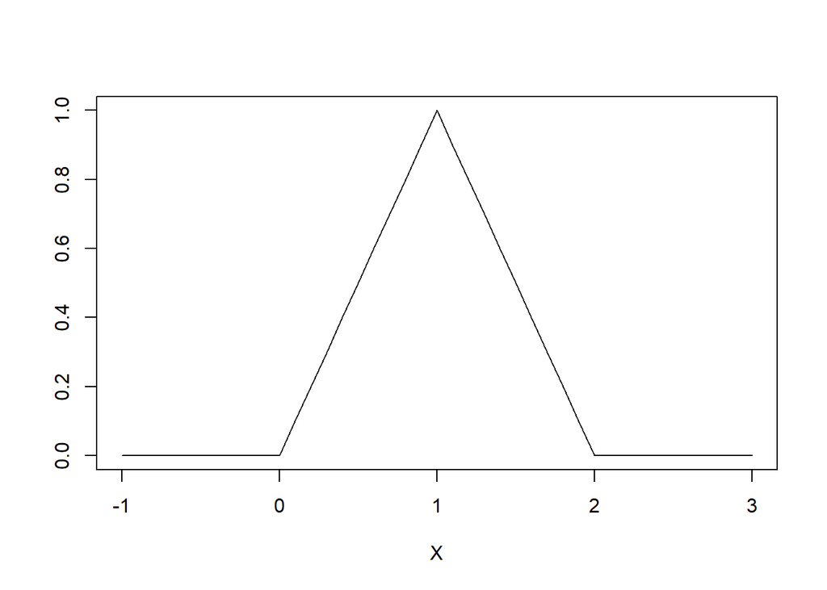

1. What is $P(X < 1)$? $P(X < 1) = \frac{1}{2}$
2. What is $P(X > 1.5)$? $P(X > 1.5) = \frac{1}{8}$
3. What is $E[X]$? $E[X] = 1$

### Problem 5

A high voltage spark can be used to create tiny aerosol particles of gold. These particles have diameters which vary according to a normal distribution with mean 1.35nm and standard deviation 0.24nm.

1. What proportion of these particles have diameter less than 1nm?

```r
x<-rnorm(10000,1.35,0.24)
mean(x<1)
```

```
## [1] 0.0696
```

2. What proportion of these particles have diameter larger than 2nm?

```r
mean(x>2)
```

```
## [1] 0.0029
```

### Problem 6

Back in 2006, the website MySpace leaked a large number of its user’s passwords. The passwords had this distribution:

- Numbers only: 1.3%
- Letters only: 9.5%
- Alphanumeric (both letters and numbers): 81%
- Includes symbols: 8.2%
1. What is the probability that a MySpace user had no Symbols in their password? $1-.082= 0.918$
2. If you chose 10 MySpace users at random, what is the probability that all of them had Alphanumeric passwords?

```r
x<- replicate(10000,sum(sample(c('N','L','AN','S'), 10, replace=TRUE,prob=c(.013,.095,.81,.082)) == 'AN'))
mean(x==10)
```

```
## [1] 0.1179
```

### Problem 7

Let $X$ and $Y$ be normal random variables with mean 10 and sd 5.

Find the expected distance from the point $(X,Y)$ to the origin $(0,0)$.

```r
sqrt((10^2)+(10^2))
```

```
## [1] 14.14214
```

### Problem 8

The `ChestSizes` data from the `HistData` library has measurements of Scottish Militiamen. There are two variables: `chest`, which gives the chest size in inches, and `count` which gives the number of soldiers with that chest size.

1. Calculate the total number of soldiers by summing the `count` variable.

```r
sum(HistData::ChestSizes$count)
```

```
## [1] 5738
```

2. Calculate the mean chest size by summing (chest size)*(count)/(total number of soldiers).

```r
sum((HistData::ChestSizes$count)*(HistData::ChestSizes$chest))/sum(HistData::ChestSizes$count)
```

```
## [1] 39.83182
```

### Problem 9

Continue with `HistData::ChestSizes`.

1. Plot the distribution of chest sizes with `chest` on the $x$-axis and `count` on the $y$-axis.

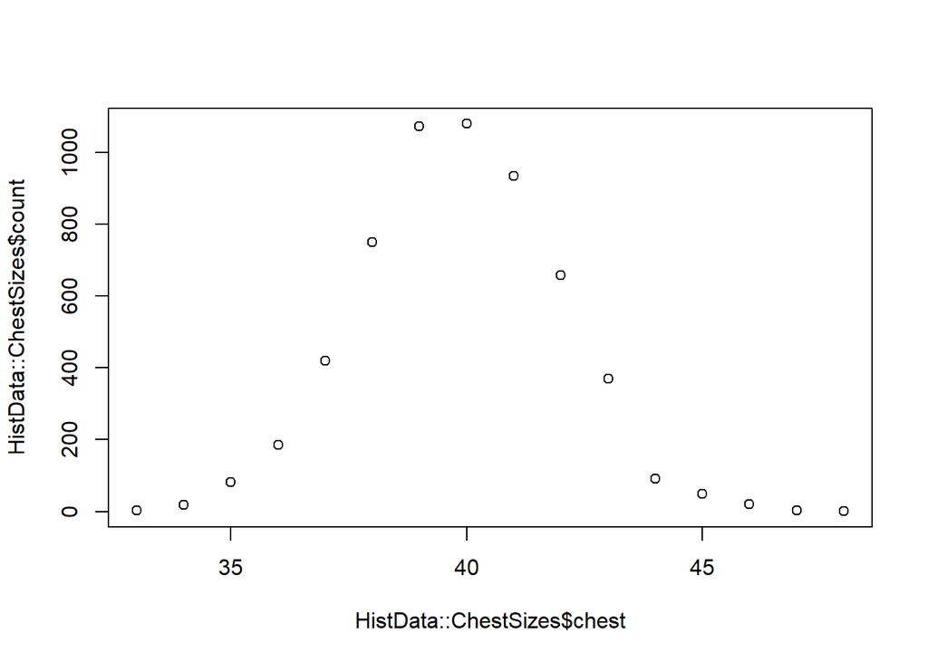

```r
plot(HistData::ChestSizes$chest,HistData::ChestSizes$count)
```

b. What sort of random variable could model this distribution? Normal RV

3. From your plot, estimate (by eye) the mean and standard deviation of chest sizes. Mean: 40, sd: 2